# GLM para dados contínuos

Layla Paiva

## 1 Modelo Linear Generalizado para Dados Contínuos

Dados contínuos são aqueles que se apresentam em números fracionários. São valores que podem ser quebrados e apresentar decimais, pois representam medidas, como por exemplo altura, peso, etc.

## 2 Na prática

Utilizando os dados disponíveis na pasta `/Dados` da disciplina, escolhi a base de dados `/fisheries.rds`, referente a um estudo sobre a pesca de atum e a coleta incidente de outras espécies não alvo.

```r
# 1. Importando o banco de dados
dados <- readRDS("~/Disciplinas do Mestrado/ECL0072 - MODELOS LINEARES GENERALIZADOS E ADITIVOS PARA DADOS ECOLÓGICOS/ECL0072-GLM_GAM-gh-pages/ECL0072-GLM_GAM-gh-pages/Dados/fisheries.rds")

#Pacotes que serão utilizados
library(ggplot2)
library(MASS) #seleção automática de modelos
library(dplyr)
library(DHARMa)
library(ggeffects) #para plotar os resultados
library(performance)
```

## 3 Análise Exploratória

Entendendo os dados e como estes se dispõem no arquivo.

```r
# Análise Exploratória
str(dados)
```

```
## 'data.frame':    476 obs. of  33 variables:
##  $ Ano                     : int  2003 2003 2003 2003 2003 2003 2003 2003 2003 2003 ...
##  $ Mes                     : int  1 1 1 1 1 1 1 1 1 1 ...
##  $ N_anzol                 : int  1050 1050 1050 1050 1050 980 955 960 960 1052 ...
##  $ Barco                   : chr  "V201" "V201" "V201" "V201" ...
##  $ Pais                    : Factor w/ 3 levels "A","B","C": 2 2 2 2 2 2 2 2 2 2 ...
##  $ Long                    : num  -33.3 -38.8 -38.1 -35.8 -36.9 ...
##  $ Lat                     : num  -27.855 0.399 -15.695 -1.997 -19.667 ...
##  $ Thunnus_albacares       : num  4 27 5 55 7 11 29 58 6 14 ...
##  $ Thunnus_atlanticus      : num  0 32 0 0 4 18 0 0 4 13 ...
##  $ Katsuwonus_pelamis      : num  5 0 7 0 5 0 36 0 0 7 ...
##  $ Xiphias_gladius         : num  0 0 0 0 0 0 0 0 2 0 ...
##  $ Istiophorus_albicans    : num  3 0 0 11 0 5 0 12 3 0 ...
##  $ Tetrapturus_albidus     : num  3 6 0 0 2 7 0 0 2 0 ...
##  $ Makaira_nigricans       : num  0 0 0 0 0 0 0 0 0 0 ...
```

[output cut: 19 more lines]

```r
summary(dados)
```

```
##       Ano            Mes          N_anzol        Barco           Pais
##  Min.   :2003   Min.   : 1.0   Min.   : 800   Length:476         A:123
##  1st Qu.:2003   1st Qu.: 4.0   1st Qu.:1000   Class :character   B:322
##  Median :2003   Median : 7.0   Median :1050   Mode  :character   C: 31
##  Mean   :2003   Mean   : 6.7   Mean   :1058
##  3rd Qu.:2003   3rd Qu.: 9.0   3rd Qu.:1100
##  Max.   :2003   Max.   :12.0   Max.   :3960
##       Long             Lat           Thunnus_albacares Thunnus_atlanticus
##  Min.   :-46.13   Min.   :-31.9000   Min.   : 0.00     Min.   : 0.000
##  1st Qu.:-37.26   1st Qu.:-20.4858   1st Qu.: 3.00     1st Qu.: 0.000
##  Median :-34.74   Median :-13.3669   Median : 7.00     Median : 5.000
##  Mean   :-34.59   Mean   :-10.6104   Mean   :12.62     Mean   : 9.462
##  3rd Qu.:-31.86   3rd Qu.:  0.1119   3rd Qu.:19.00     3rd Qu.:11.000
##  Max.   :-22.43   Max.   : 15.1622   Max.   :58.00     Max.   :51.000
##  Katsuwonus_pelamis Xiphias_gladius  Istiophorus_albicans Tetrapturus_albidus
##  Min.   : 0.000     Min.   : 0.000   Min.   : 0.000       Min.   : 0.000
##  1st Qu.: 0.000     1st Qu.: 0.000   1st Qu.: 0.000       1st Qu.: 0.000
##  Median : 4.000     Median : 0.000   Median : 0.000       Median : 0.000
##  Mean   : 8.286     Mean   : 1.643   Mean   : 1.147       Mean   : 1.517
##  3rd Qu.: 9.000     3rd Qu.: 2.000   3rd Qu.: 1.000       3rd Qu.: 2.000
##  Max.   :51.000     Max.   :19.000   Max.   :18.000       Max.   :19.000
##  Makaira_nigricans Ruvettus_pretiosus Coryphaena_hippurus
##  Min.   : 0.000    Min.   : 0.000     Min.   : 0.000
##  1st Qu.: 0.000    1st Qu.: 0.000     1st Qu.: 0.000
##  Median : 0.000    Median : 0.000     Median : 1.000
##  Mean   : 0.687    Mean   : 1.439     Mean   : 2.315
##  3rd Qu.: 0.000    3rd Qu.: 2.000     3rd Qu.: 3.000
##  Max.   :13.000    Max.   :12.000     Max.   :17.000
##  Acanthocybium_solandri   Mola_mola         Teleosteos     Prionace_glauca
##  Min.   : 0.000         Min.   : 0.0000   Min.   : 0.000   Min.   : 0.00
##  1st Qu.: 0.000         1st Qu.: 0.0000   1st Qu.: 0.000   1st Qu.: 0.00
##  Median : 1.000         Median : 0.0000   Median : 0.000   Median : 5.00
##  Mean   : 1.952         Mean   : 0.7521   Mean   : 1.899   Mean   :10.18
##  3rd Qu.: 3.000         3rd Qu.: 0.0000   3rd Qu.: 3.000   3rd Qu.:14.25
##  Max.   :13.000         Max.   :13.0000   Max.   :18.000   Max.   :55.00
##  Sphyrna_lewini   Alopias_vulpinus Aphanopus_carbo   Isurus_oxyrinchus
##  Min.   : 0.000   Min.   : 0.000   Min.   : 0.0000   Min.   : 0.0000
##  1st Qu.: 0.000   1st Qu.: 0.000   1st Qu.: 0.0000   1st Qu.: 0.0000
##  Median : 1.000   Median : 0.000   Median : 0.0000   Median : 0.0000
##  Mean   : 2.319   Mean   : 1.779   Mean   : 0.7962   Mean   : 0.7122
```

[output cut: 8 more lines]

```
##  Max.   :15.000           Max.   :18.0000   Max.   :20.00   Max.   :29.10
##       sal                chla             depth              dlm
##  Min.   :-11.9733   Min.   :0.02634   Min.   :-5655.4   Min.   : 23.61
##  1st Qu.: -0.6906   1st Qu.:0.07520   1st Qu.:-4972.4   1st Qu.: 56.87
##  Median :  2.0109   Median :0.11485   Median :-4422.1   Median : 69.52
##  Mean   :  2.1848   Mean   :0.11489   Mean   :-4259.4   Mean   : 65.73
##  3rd Qu.:  5.0789   3rd Qu.:0.14127   3rd Qu.:-3812.7   3rd Qu.: 75.80
##  Max.   : 23.4807   Max.   :0.45787   Max.   : -311.3   Max.   :101.97
##        il
##  Min.   :0.0000
##  1st Qu.:0.1800
##  Median :0.5200
##  Mean   :0.5156
##  3rd Qu.:0.8800
##  Max.   :1.0000
```

O arquivo possui 476 linhas de dados e 33 variáveis, das quais, as 7 primeiras colunas são referentes à identificação de cada local de amostragem e coleta, seguidas de 20 espécies que foram coletadas, finalizando com 6 colunas com fatores ambientais.

A pergunta da análise será: Os fatores oceanográficos, espaço-temporais e pesqueiros influenciam na captura das espécies alvo?

Nesse sentido, a variável dependente (Y) será uma nova medida, chamada captura-por-unidade-de-esforço (CPUE), calculada a partir do número total de peixes alvo capturados por amostra.

Já as variáveis independentes (X) serão: - sst: temperatura do mar - sal: salinidade do mar - depth: profundidade do leito marinho em que ocorreu a pescaria - il: índice lunar

###Convertendo a natureza das variáveis

Como as análises serão feitas com variáveis numéricas, não é necessário conversão.

### 3.1 Entendendo as variáveis

Selecionando as espécies

```r
especies_alvo <- c("Thunnus_albacares",
                   "Thunnus_atlanticus",
                   "Katsuwonus_pelamis",
                   "Prionace_glauca")
```

Calculando o CPUE:

```r
library(dplyr)
#Número de peixes alvo por N de anzol
dados <- dados %>%
         rowwise() %>%  # analisa linha por linha
         mutate(Bycatch = sum(c_across(all_of(especies_alvo))),
                CPUE = Bycatch/N_anzol) %>%
         data.frame()
```

Vizualizando as possíveis relações:

É possível que as diferentes profundidades em que ocorreu a pesca e o índice lunar possa ter afetado as capturas.

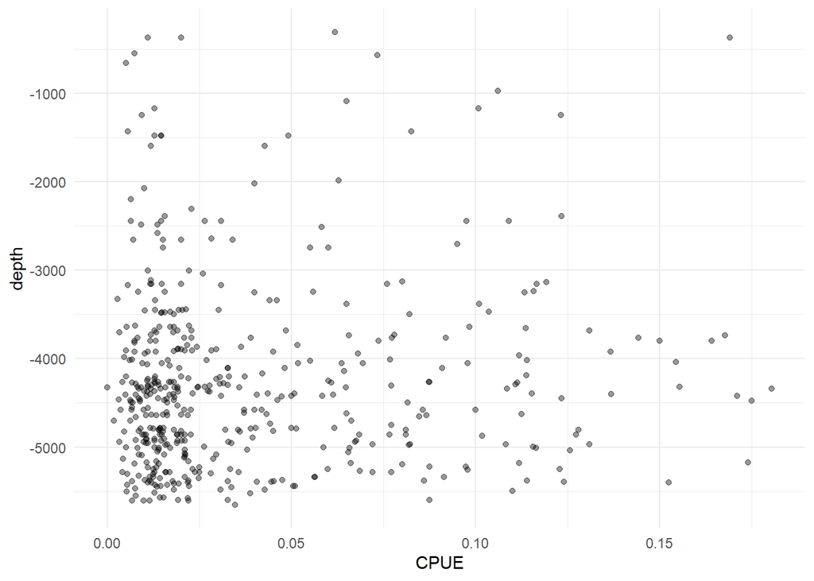

```r
library(ggplot2)
#Relação entre captura por unidade de esforço e profundidade de coleta
ggplot(dados, aes(CPUE, depth)) +
  geom_point(alpha = 0.4) +
  theme_minimal()
```

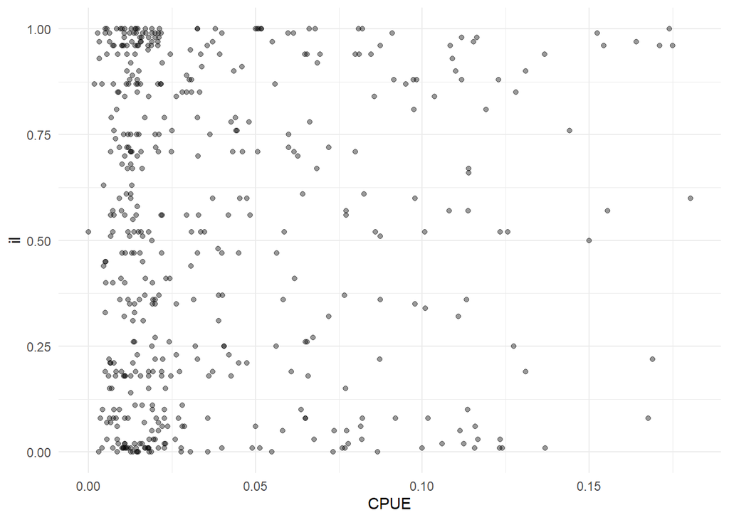

```r
#Relação entre captura por unidade de esforço e índice lunar
ggplot(dados, aes(CPUE, il)) +
  geom_point(alpha = 0.4) +
  theme_minimal()
```

Além disso, as outras variáveis ambientais também podem ter afetado as capturas:

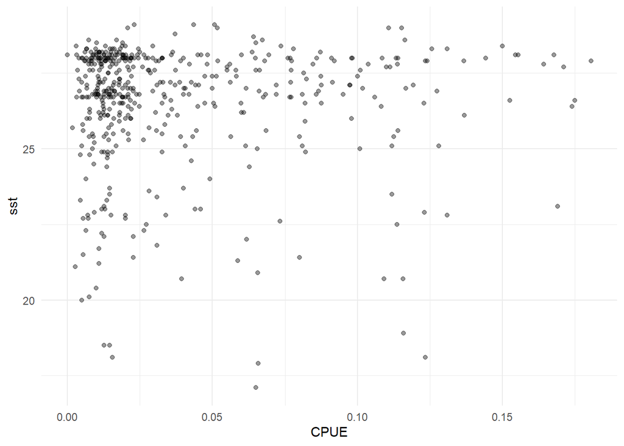

```r
#Relação entre captura por unidade de esforço e temperatura do mar
ggplot(dados, aes(CPUE, sst)) +
  geom_point(alpha = 0.4) +
  theme_minimal()
```

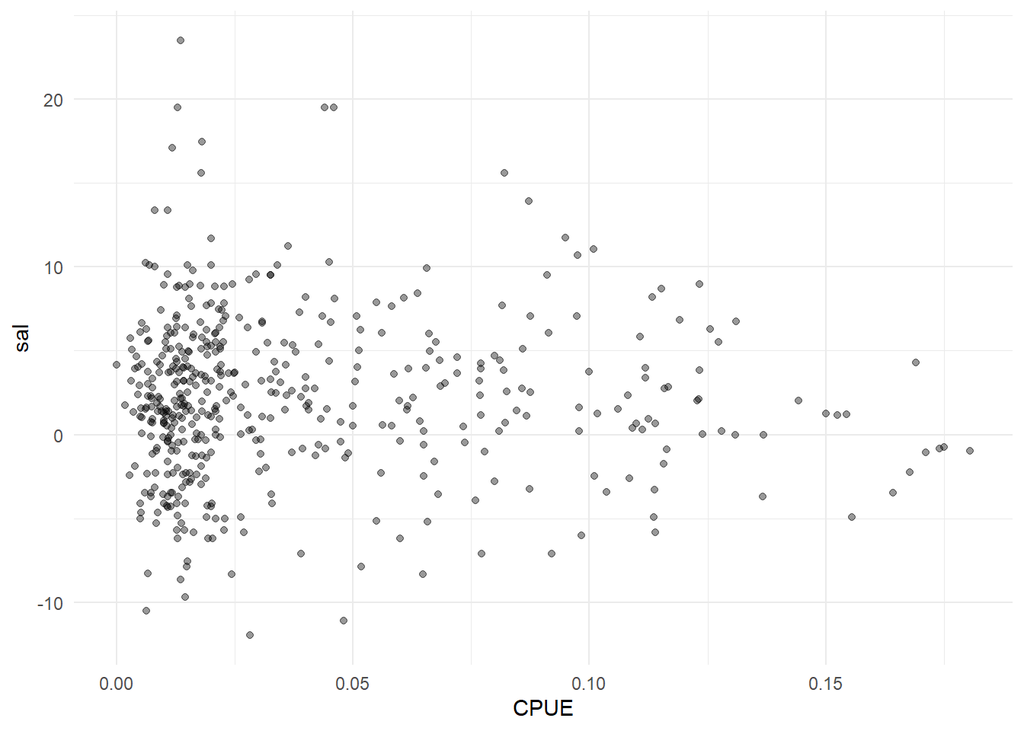

```r
#Relação entre captura por unidade de esforço e salinidade do mar
ggplot(dados, aes(CPUE, sal)) +
  geom_point(alpha = 0.4) +
  theme_minimal()
```

## Hipóteses

Com as análises iniciais, podemos formar nossas hipóteses!

- $H_1:$ A temperatura do mar influencia a captura por unidade de esforço
- $H_2:$ A profundidade de coleta do mar influencia a captura por unidade de esforço
- $H_3:$ O índice lunar influencia a captura por unidade de esforço
- $H_4:$ A salinidade do mar influencia a captura por unidade de esforço

##Objetivos

Avaliar como fatores ambientais marinhos influenciam a captura por unidade de esforço amostral na pesca de atum.

###Objetivos Específicos

1. **Avaliar o efeito da temperatura do mar na captura dos peixes alvo**
   - Permitirá determinar se o número de peixes alvo capturados difere significativamente entre ambientes mais ou menos quentes.
2. **Avaliar o efeito da profundidade do mar na captura dos peixes alvo** - Permitirá determinar se o número de peixes alvo capturados difere significativamente entre ambientes de coleta mais ou menos profundos.
3. **Avaliar o efeito do índice lunar na captura dos peixes alvo** - Permitirá determinar se o número de peixes alvo capturados difere significativamente durante o ciclo lunar.
4. **Avaliar o efeito da salinidade do mar na captura dos peixes alvo** - Permitirá determinar se o número de peixes alvo capturados difere significativamente entre ambientes mais ou menos salinos.

## 4 Análises & Resultados

Preparando os dados

```r
#verificando a presença de zeros ou inconsistências na variável y
any(dados$CPUE <= 0)
```

```
## [1] TRUE
```

```r
any(is.infinite(dados$CPUE))
```

```
## [1] FALSE
```

```r
any(is.na(dados$CPUE))
```

```
## [1] FALSE
```

```r
any(is.nan(dados$CPUE))
```

```
## [1] FALSE
```

Como Y possui zeros, vamos adicionar uma constante

```r
# Usando 10% da mediana do CPUE
dados$CPUE2 <- dados$CPUE + (0.1 * median(dados$CPUE))


# Transformando para log
dados$CPUE2_log <- log(dados$CPUE2)
```

Rodando os modelos:

```r
# Modelo Gama
modelo_G <- glm(CPUE2 ~ sst + sal + depth + il,
                family = Gamma(link = "log"),
                data = dados)


# Modelo log-Normal
modelo_LN <- glm(CPUE2_log ~ sst + sal + depth + il,
                 family = gaussian,
                 data = dados)
```

Comparando o melhor ajuste

```r
# AIC
AIC(modelo_G, modelo_LN)
```

```
##           df       AIC
## modelo_G   6 -2118.137
## modelo_LN  6  1226.856
```

```r
# Teste de razão de verossimilhança
lmtest::lrtest(modelo_LN,modelo_G)
```

```
## Likelihood ratio test
##
## Model 1: CPUE2_log ~ sst + sal + depth + il
## Model 2: CPUE2 ~ sst + sal + depth + il
##   #Df  LogLik Df Chisq Pr(>Chisq)
## 1   6 -607.43
## 2   6 1065.07  0  3345  < 2.2e-16 ***
## ---
## Signif. codes:  0 '***' 0.001 '**' 0.01 '*' 0.05 '.' 0.1 ' ' 1
```

Como valor de LogLik foi maior no modelo 2 (1065), então o modelo Gama se ajusta melhor aos dados quando comparado ao log-normal.

```r
# Checando a deviancia de cada modelo
modelo_G$deviance
```

```
## [1] 363.4653
```

```r
modelo_LN$deviance
```

```
## [1] 357.7231
```

Novamente o modelo gama apresentou valor maior (363.46).Porém, como é uma medida de deviancia, significa dizer que o modelo gama apresenta uma discrepância maior em relação ao modelo perfeito, quando comparado ao log-normal.

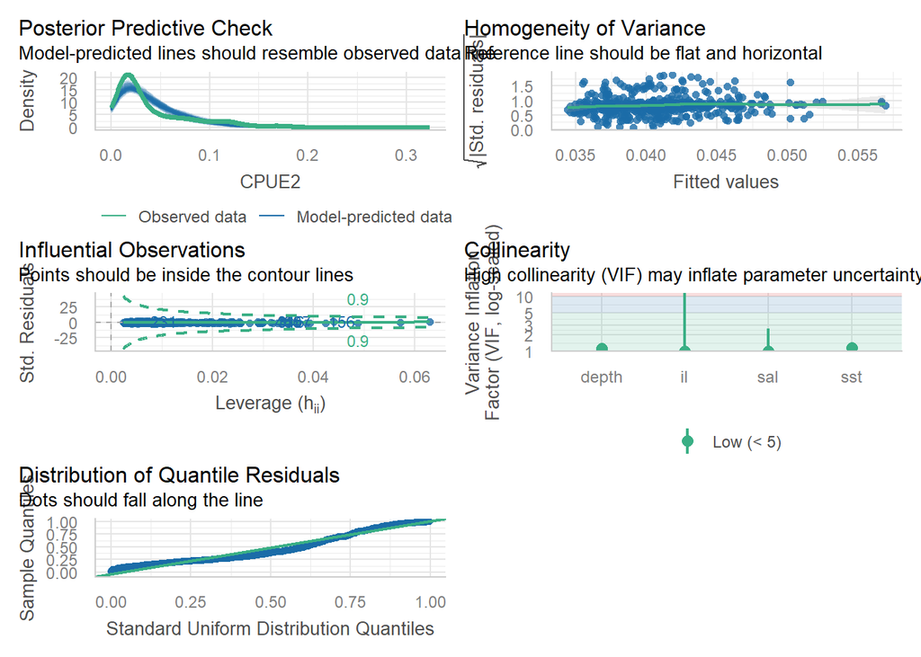

```r
# checando os Residuos de cada modelo
resG <- simulateResiduals(modelo_G, n=1000)
resLN <- simulateResiduals(modelo_LN, n=1000)

check_model(resG)
```

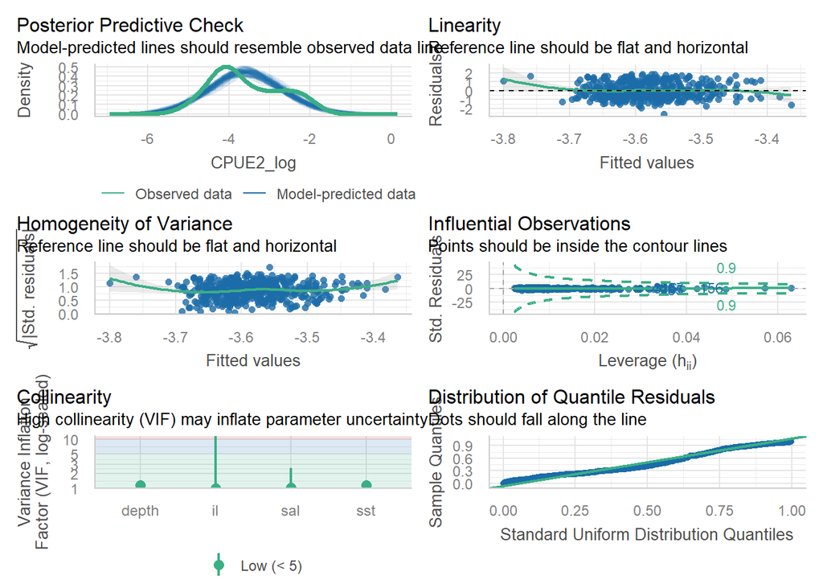

```r
check_model(resLN)
```

Os resíduos do modelo gama apresentam boa semelhança com o esperado, e boa distribuição. Não apresenta resíduos extremamente discrepantes que influencie os resultados e apresentaram baixa colinearidade. Porém, não apresentou boa homogeniedade de variância.

Os resíduos do modelo log-normal apresentaram pouco desvio do esperado, uma boa distribuição e baixa colinearidade. Assim como no primeiro modelo, apresentou alta variância, mas também baixa linearidade.

Entendendo os resultados

```r
summary(modelo_G)
```

```
##
## Call:
## glm(formula = CPUE2 ~ sst + sal + depth + il, family = Gamma(link = "log"),
##     data = dados)
##
## Coefficients:
##               Estimate Std. Error t value Pr(>|t|)
## (Intercept) -3.103e+00  5.660e-01  -5.483 6.84e-08 ***
## sst          5.560e-03  2.238e-02   0.248    0.804
## sal         -4.615e-03  8.861e-03  -0.521    0.603
## depth        7.202e-05  4.385e-05   1.642    0.101
## il           1.364e-01  1.192e-01   1.144    0.253
## ---
## Signif. codes:  0 '***' 0.001 '**' 0.01 '*' 0.05 '.' 0.1 ' ' 1
##
## (Dispersion parameter for Gamma family taken to be 0.8713539)
##
##     Null deviance: 367.02  on 475  degrees of freedom
## Residual deviance: 363.47  on 471  degrees of freedom
## AIC: -2118.1
##
## Number of Fisher Scoring iterations: 7
```

De modo geral, o modelo Gama se apresentou mais ajustado para os dados utilizados.

Analizando as predições

```r
names(modelo_G)
```

```
##  [1] "coefficients"      "residuals"         "fitted.values"
##  [4] "effects"           "R"                 "rank"
##  [7] "qr"                "family"            "linear.predictors"
## [10] "deviance"          "aic"               "null.deviance"
## [13] "iter"              "weights"           "prior.weights"
## [16] "df.residual"       "df.null"           "y"
## [19] "converged"         "boundary"          "model"
## [22] "call"              "formula"           "terms"
## [25] "data"              "offset"            "control"
## [28] "method"            "contrasts"         "xlevels"
```

```r
head(cbind(modelo_G$fitted.values, modelo_G$linear.predictors))
```

```
##         [,1]      [,2]
## 1 0.03626752 -3.316833
## 2 0.03577614 -3.330474
## 3 0.03462381 -3.363214
## 4 0.03898675 -3.244533
## 5 0.03462381 -3.363214
## 6 0.03623572 -3.317710
```

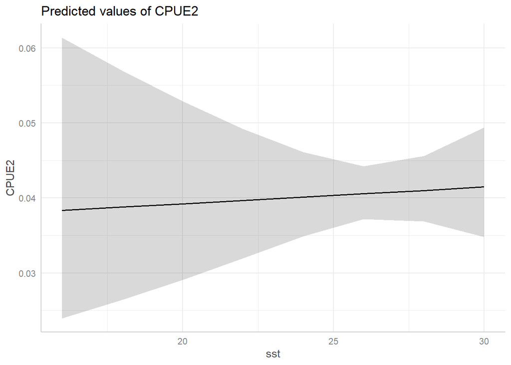

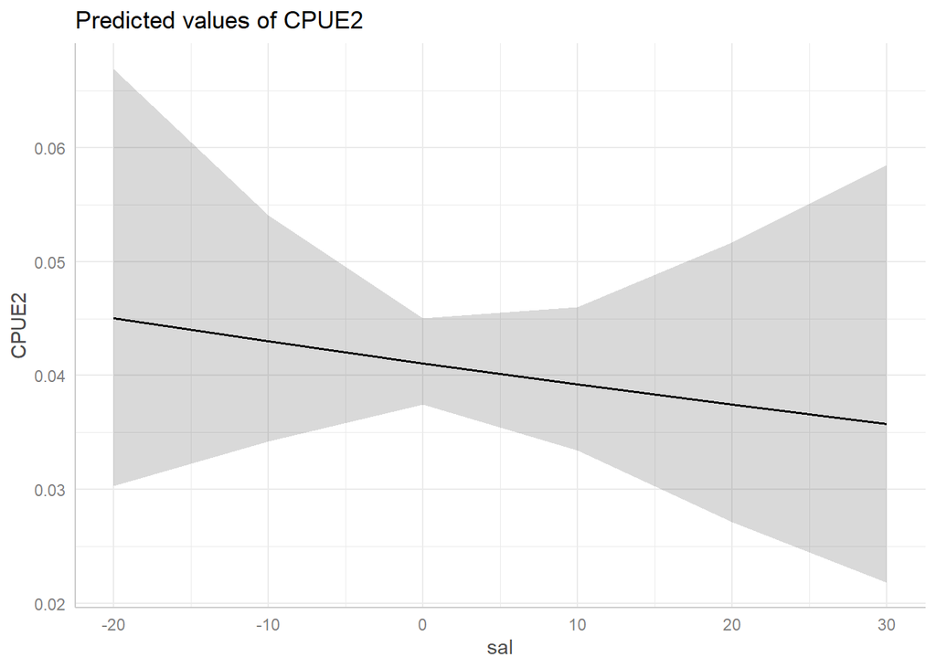

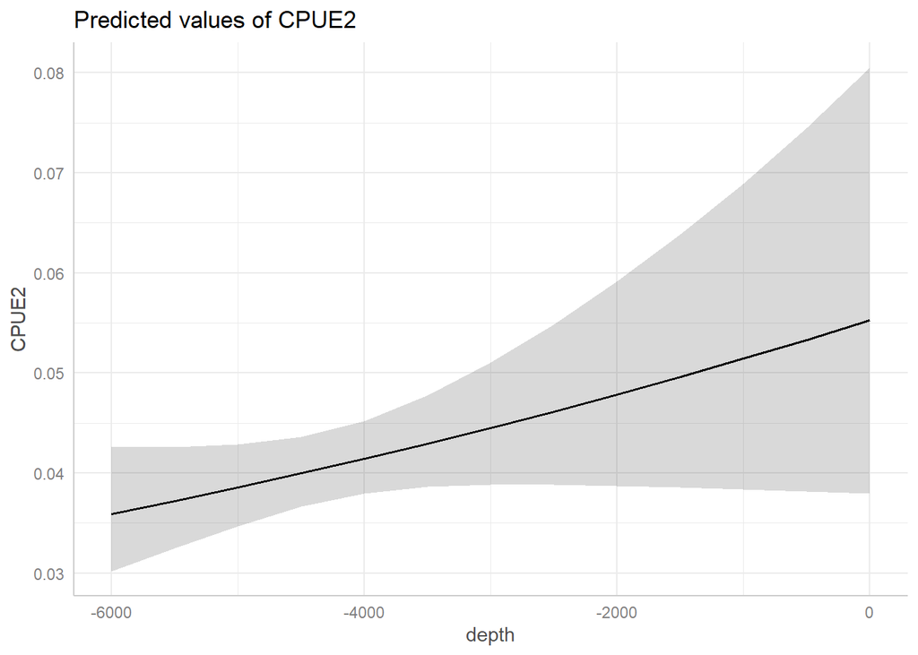

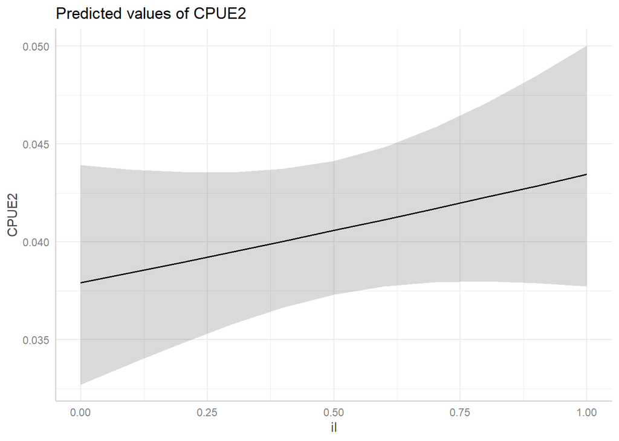

```r
ggpredict(modelo_G) %>% plot()
```